# Helping Researchers Find The Way

Optimising the Preparation of Analytical-Ready Geospatial Datasets

Chris Wood, Mark Sawyer

EPCC, University of Edinburgh

## What problem are we trying to solve?

- Anecodotal evidence that researchers spend a huge amount of time wrangling data, or not be aware of what datasets exist
- Scottish Government holds many disparate datasets
  - …many of which are geospatially labelled (i.e. contain latitude / longitude or OSGB variables)

**Can we link any of these together to create new, derived datasets that are of use to researchers from a wide range of domains?**

OSGB is Ordnance Survey National Grid: flattened grid; 0-indexed from just South-West of Isles of Scilly. Numbers (*eastings* and *northings*) are offset metres from `(0,0)`. We’re currently at `433652,387246`

## First proof-of-concept research question

**What is the walking distance from each residential address in Scotland to its nearest GP surgery?**

Initial unknowns:

- how easy data cleaning would be
- run time
- potential optimisations

## The issue with islands

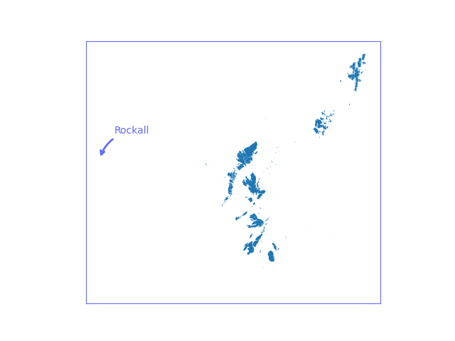

Scotland has 6901 islands

…142 inhabited

…only 24 have GPs

- Skye has a bridge 🌉
  - treat as mainland
- **optimisation #1**: remove uninhabited islands from dataset
- **optimisation #2**: remove islands without a GP surgery from dataset
- treat all islands as special cases and ignore initially: reason to become clear!

## The data: residential data

Every “addressable structure” in the UK has a *UPRN*

- This is a hierarchy: individual properties in a block of flats also have their own unique UPRN
- The Ordnance Survey Address Base has a classification for every structure
- CSV format: importable into Pandas & filter structures which have a residential classification

**2,821,534** residential UPRNs in Scotland

#### Caveat

- AddressBase is published by OS, but Local Authorities update their own area
- we have found some minor inconsistencies

## The data: GP Surgeries

Less straightforward

There are *two* official lists of GPs in Scotland:

- OpenData Scotland
  - more frequently updated (quarterly)
- Spatial DataHub Scotland
  - richer data (contains UPRN), but last updated October 2020
- Luckily, both contain *Practice Code*

Unsurprisingly, lots of inconsistencies…

- some GP surgeries have moved and kept the same Practice Code
- some GP surgeries have merged
- some GP surgeries have moved and changed Practice Code

## GP Data Cleaning

1. Merge datasets together on *Practice Code* - the records that come from the older dataset contain UPRN
2. Merge with AddressBase to get lat/long of the records with UPRN
3. Remove records with either duplicates UPRN or postcode (some distinct surgeries are colocated in the same building)
4. For rows that didn’t have a UPRN, geolocate from postcode using the `postcodes.io` API

Risk: a GP surgery that moved and merged with another one, *and* changed its Practice Code, will remain in the dataset.

## Slight aside: the issue of dirty data

There are duplicates across UPRN and Postcode; there were examples of all of the following:

- multiple postcodes associated with multiple practice codes that have the same UPRN
- multiple postcodes associated with multiple practice codes that have different UPRNs
- a single postcode with multiple practice codes that have different UPRNs
- a single postcode with multiple practice codes that have the same UPRN

#### Conclusion: plan for a *lot* of data cleaning time when dealing with large datasets collated by different agencies!

## The data: map data with routing capabilities

[figure not shown]

- OpenStreetMap to the rescue!
- (plus: `pyorsm`, `networkx`, and `osmnx` Python libraries)

## The tools

```python
from concurrent.futures import ProcessPoolExecutor
import datetime
import json
import requests
import math
import statistics as stats
import time
import yaml

import numpy as np

import pandas as pd
from pandas.testing import assert_frame_equal

import geopandas as gpd

from pyrosm import OSM
import networkx as nx
import osmnx as ox

from shapely import Point
from shapely.geometry import Polygon
from shapely.ops import transform
```

## Graph example

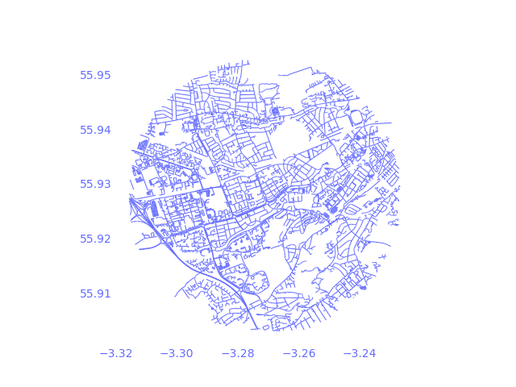

## Edinburgh: initial naïve methods..

To get an idea of feasability for whole of Scotland in one go…

[figure not shown]

* For testing, all GPs were geolocated based on postcode

## Edinburgh results

- Area: 273 km<sup>2</sup>
- UPRNs: 372912
- Unique GP locations: 61 (but 71 GP Practices)

|  | Walking | Driving |
| --- | --- | --- |
| edges | 1174124 | 625848 |
| time | 20307 | 11804 |
| mean | 833.61 | 1029.27 |
| std | 537.99 | 713.85 |
| min | 0.00 | 0.00 |
| 50% | 733.00 | 880.00 |
| max | 11540.00 | 19288.00 |

## Scotland-wide: optimisations

- **Group UPRNs by GP**
  - reduces size of graph
  - but treat islands separately
- **Get all nodes in one call**
  - `osmnx.distance.nearest_nodes` is vectorised
- **Distances to nodes, not UPRNs**
  - ~90% reduction in calculations needed in urban areas
- **Distribute reading in graph**
  - calculation of distances is relatively fast in small graphs
  - but beware of memory leaks!

## Results

- results output to JSON (1 file of metadata + summaries per GP practice) + CSV, plus a single summary CSV
- 693 GPs (+ 3 unknown)
- ~3990 uprns per GP
- 1183 km<sup>2</sup> average area *but* standard deviation of 2132!

|  | Walking | Driving |
| --- | --- | --- |
| nodes | 1181 | 1079 |
| time | 248 | 238 |
| mean | 2536 | 2713 |
| 50% | 1915 | 2099 |
| max | 10981 | 13028 |
| std | 2237 | 2413 |

## Future work

- Optimise how to deal with the islands
  - should we factor in ferries for transport?
- Results by e.g. Council Areas
- Future points of interest?
  - pharmacies
  - schools
  - railway stations
  - bus stops
  - …
- make derived datasets available via relevant (meta)data catalogues
- publicise to researchers

## tl;dr

- what work is needed to generate the travel distance from all households in Scotland to its nearest GP surgery?
- data:
  - OpenStreetMap + AddressBase + GP surgeries
- tools
  - well maintained libraries in the Python ecosystem
  - `GeoPandas` + `pyrosm` + `osmnx` + `networkx` (+ `postcodes.io`)
- embarassingly parallel: easily optimised
  - graph generation is main bottleneck
- walking and driving distances generated in <2 hours
- **data cleaning is time consuming!**

### Acknowledgements

Funding:

- Economic and Social Research Council via Administrative Data Research Scotland (UKRI3324)

Data and useful discussions:

- Alex Ramage (Scottish Government)
- Chris Dibben (University of Edinburgh)

### Thanks!

c.wood@epcc.ed.ac.uk

## Useful Geopandas code!

```python
islands.clip(geo_gps)
```